# MBA6693 - Business Analytics

Shubh Sharma

## 1. Introduction

This assignment is aimed at building regression models for the Taiwanese Real Estate Valuation problem and selecting the best model among the proposed ones on the basis of various observations that will me make.

```r
library(scatterplot3d)
library(corrplot)
library(ggiraphExtra)
library(ggplot2)
library(broom)
library(readxl)
Real_estate_valuation_data_set <- read_excel("C:/Users/casa/Downloads/Real estate valuation data set.xlsx")
colnames(Real_estate_valuation_data_set)[colnames(Real_estate_valuation_data_set) == "X1 transaction date"] <- "x1"
colnames(Real_estate_valuation_data_set)[colnames(Real_estate_valuation_data_set) == "X2 house age"] <- "x2"
colnames(Real_estate_valuation_data_set)[colnames(Real_estate_valuation_data_set) == "X3 distance to the nearest MRT station"] <- "x3"
colnames(Real_estate_valuation_data_set)[colnames(Real_estate_valuation_data_set) == "X4 number of convenience stores"] <- "x4"
colnames(Real_estate_valuation_data_set)[colnames(Real_estate_valuation_data_set) == "X5 latitude"] <- "x5"
colnames(Real_estate_valuation_data_set)[colnames(Real_estate_valuation_data_set) == "X6 longitude"] <- "x6"
colnames(Real_estate_valuation_data_set)[colnames(Real_estate_valuation_data_set) == "Y house price of unit area"] <- "y"
```

## 2. Data Description

Data taken from: https://archive.ics.uci.edu/ml/datasets/Real+estate+valuation+data+set#

### Data Set Information

The market historical data set of real estate valuation are collected from Sindian Dist., New Taipei City, Taiwan. This is a regression problem. The data set was randomly split into the training data set (2/3 samples) and the testing data set (1/3 samples).

### Attribute Information

The inputs are as follows:

```
X1=the transaction date (for example, 2013.250=2013 March, 2013.500=2013 June, etc.)
X2=the house age (unit: year)
X3=the distance to the nearest MRT station (unit: meter)
X4=the number of convenience stores in the living circle on foot (integer)
X5=the geographic coordinate, latitude. (unit: degree)
X6=the geographic coordinate, longitude. (unit: degree)
```

The output is as follows:

```
Y= house price of unit area (10000 New Taiwan Dollar/Ping, where Ping is a local unit, 1 Ping = 3.3 meter squared)
```

Relevant Papers: Yeh, I. C., & Hsu, T. K. (2018). Building real estate valuation models with comparative approach through case-based reasoning. Applied Soft Computing, 65, 260-271.

### Data preprocessing

```
colnames(Real_estate_valuation_data_set)[colnames(Real_estate_valuation_data_set) == "X1 transaction date"] <- "x1"
colnames(Real_estate_valuation_data_set)[colnames(Real_estate_valuation_data_set) == "X2 house age"] <- "x2"
colnames(Real_estate_valuation_data_set)[colnames(Real_estate_valuation_data_set) == "X3 distance to the nearest MRT station"] <- "x3"
colnames(Real_estate_valuation_data_set)[colnames(Real_estate_valuation_data_set) == "X4 number of convenience stores"] <- "x4"
colnames(Real_estate_valuation_data_set)[colnames(Real_estate_valuation_data_set) == "X5 latitude"] <- "x5"
colnames(Real_estate_valuation_data_set)[colnames(Real_estate_valuation_data_set) == "X6 longitude"] <- "x6"
colnames(Real_estate_valuation_data_set)[colnames(Real_estate_valuation_data_set) == "Y house price of unit area"] <- "y"
```

## 3. Exploratory Analysis

### Univariate Analysis

Structure of the dataset

```r
str(Real_estate_valuation_data_set)
```

```
## tibble [414 x 7] (S3: tbl_df/tbl/data.frame)
##  $ x1: num [1:414] 2013 2013 2014 2014 2013 ...
##  $ x2: num [1:414] 32 19.5 13.3 13.3 5 7.1 34.5 20.3 31.7 17.9 ...
##  $ x3: num [1:414] 84.9 306.6 562 562 390.6 ...
##  $ x4: num [1:414] 10 9 5 5 5 3 7 6 1 3 ...
##  $ x5: num [1:414] 25 25 25 25 25 ...
##  $ x6: num [1:414] 122 122 122 122 122 ...
##  $ y : num [1:414] 37.9 42.2 47.3 54.8 43.1 32.1 40.3 46.7 18.8 22.1 ...
```

```r
summary(Real_estate_valuation_data_set)
```

```
##        x1             x2               x3                x4
##  Min.   :2013   Min.   : 0.000   Min.   :  23.38   Min.   : 0.000
##  1st Qu.:2013   1st Qu.: 9.025   1st Qu.: 289.32   1st Qu.: 1.000
##  Median :2013   Median :16.100   Median : 492.23   Median : 4.000
##  Mean   :2013   Mean   :17.713   Mean   :1083.89   Mean   : 4.094
##  3rd Qu.:2013   3rd Qu.:28.150   3rd Qu.:1454.28   3rd Qu.: 6.000
##  Max.   :2014   Max.   :43.800   Max.   :6488.02   Max.   :10.000
##        x5              x6              y
##  Min.   :24.93   Min.   :121.5   Min.   :  7.60
##  1st Qu.:24.96   1st Qu.:121.5   1st Qu.: 27.70
##  Median :24.97   Median :121.5   Median : 38.45
##  Mean   :24.97   Mean   :121.5   Mean   : 37.98
##  3rd Qu.:24.98   3rd Qu.:121.5   3rd Qu.: 46.60
##  Max.   :25.01   Max.   :121.6   Max.   :117.50
```

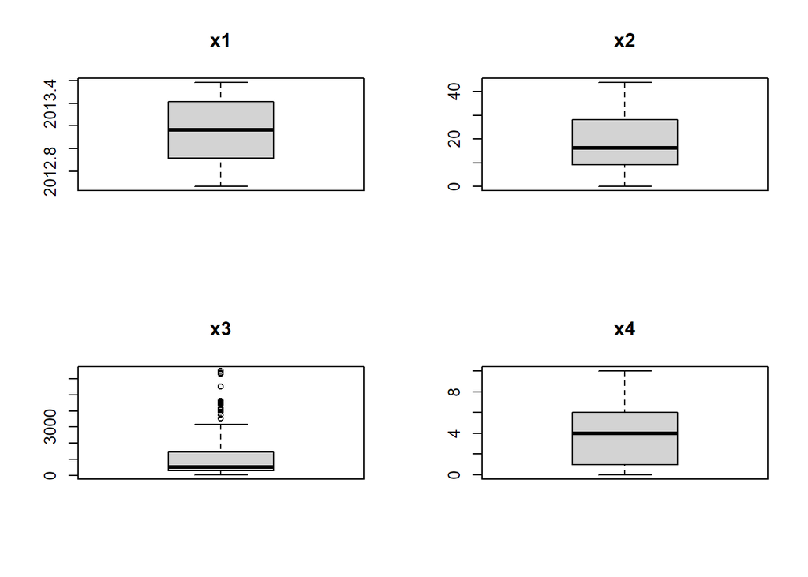

```r
par(mfrow=c(2,2))
for(i in 1:4) {
    boxplot(Real_estate_valuation_data_set[,i], main=names(Real_estate_valuation_data_set)[i])
}
```

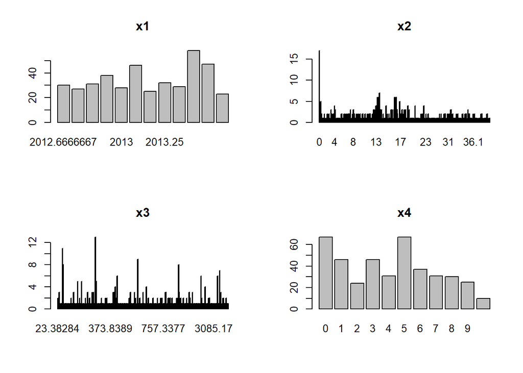

```r
par(mfrow=c(2,2))
for(i in 1:4) {
    counts <- table(Real_estate_valuation_data_set[,i])
    name <- names(Real_estate_valuation_data_set)[i]
    barplot(counts, main=name)
}
```

### Relationship between House Cost and Transaction Date

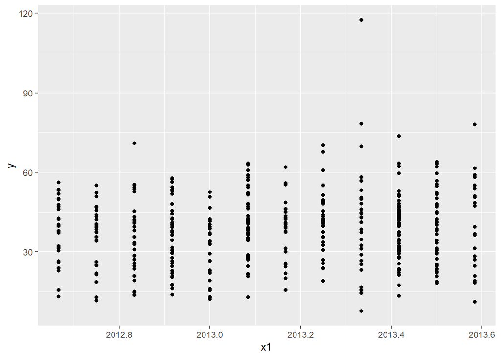

```r
ggplot(Real_estate_valuation_data_set, aes(x1,y)) + geom_point()
```

### Relationship between House Cost and Age

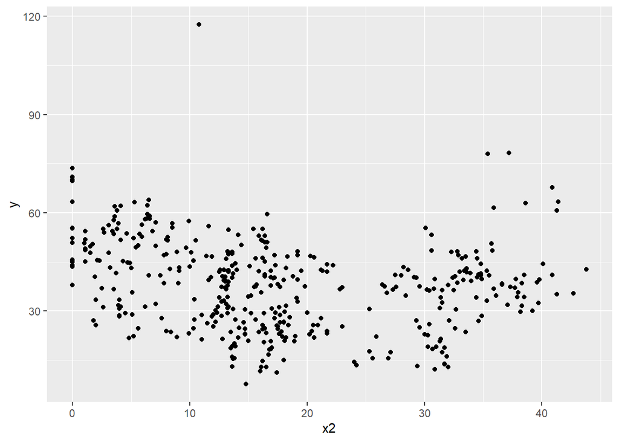

```r
ggplot(Real_estate_valuation_data_set, aes(x2,y)) + geom_point()
```

### Relationship between House Cost and Station Distance

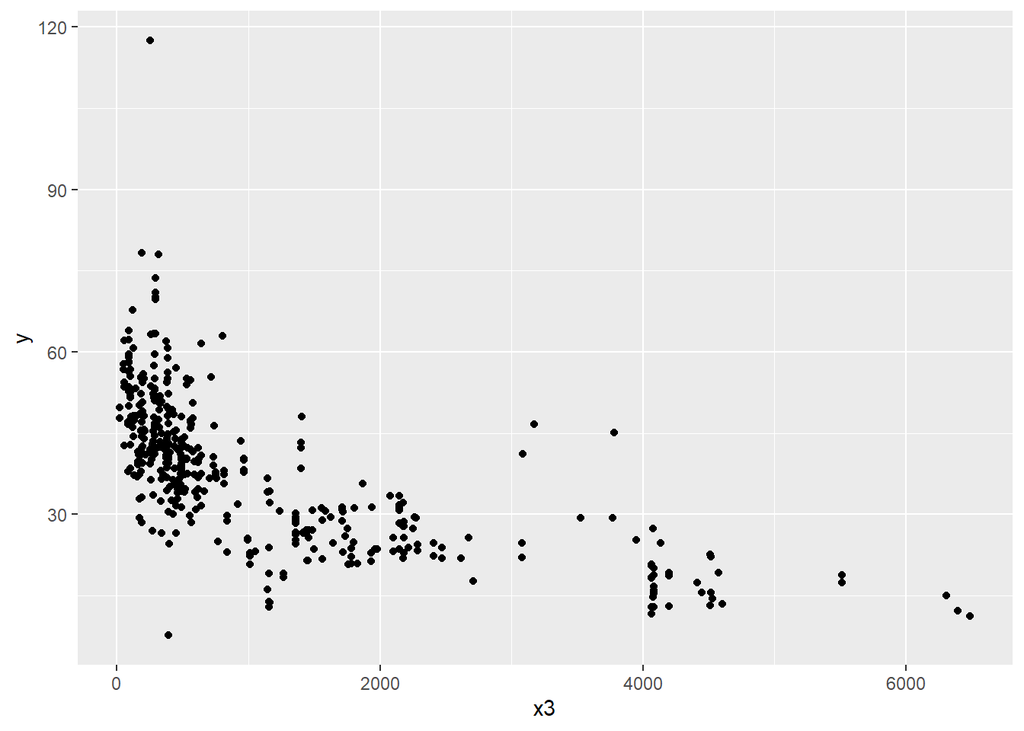

```r
ggplot(Real_estate_valuation_data_set, aes(x3,y)) + geom_point()
```

### Relationship between House Cost and No of Convenience Store

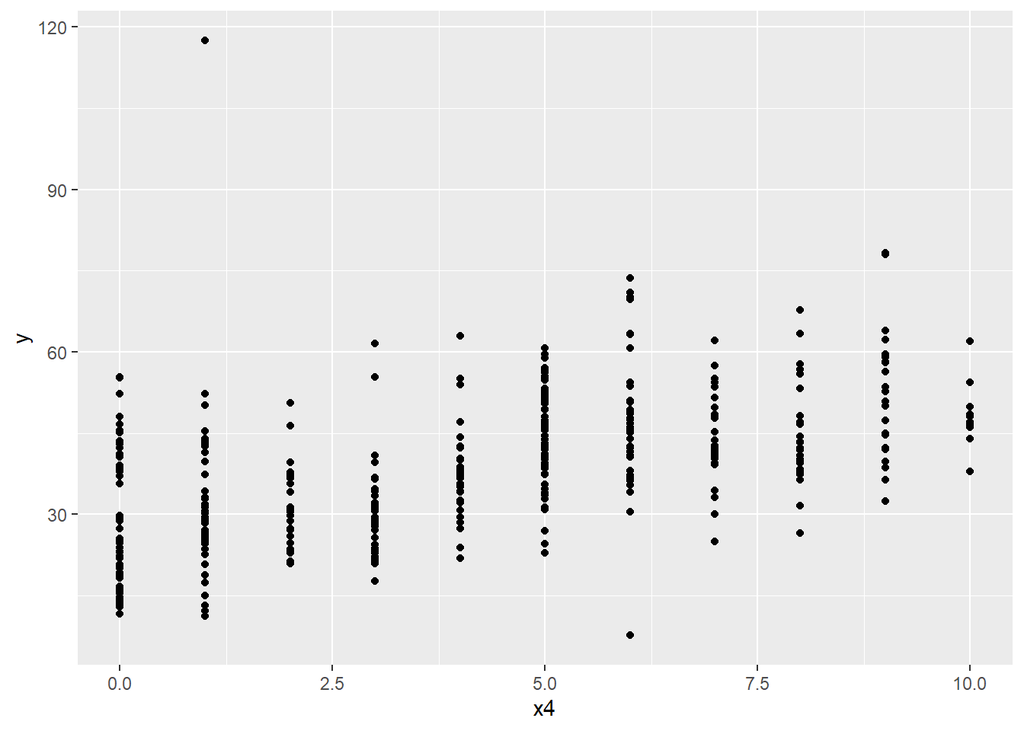

```r
ggplot(Real_estate_valuation_data_set, aes(x4,y)) + geom_point()
```

### Relationship between House Cost and X-Coordinate

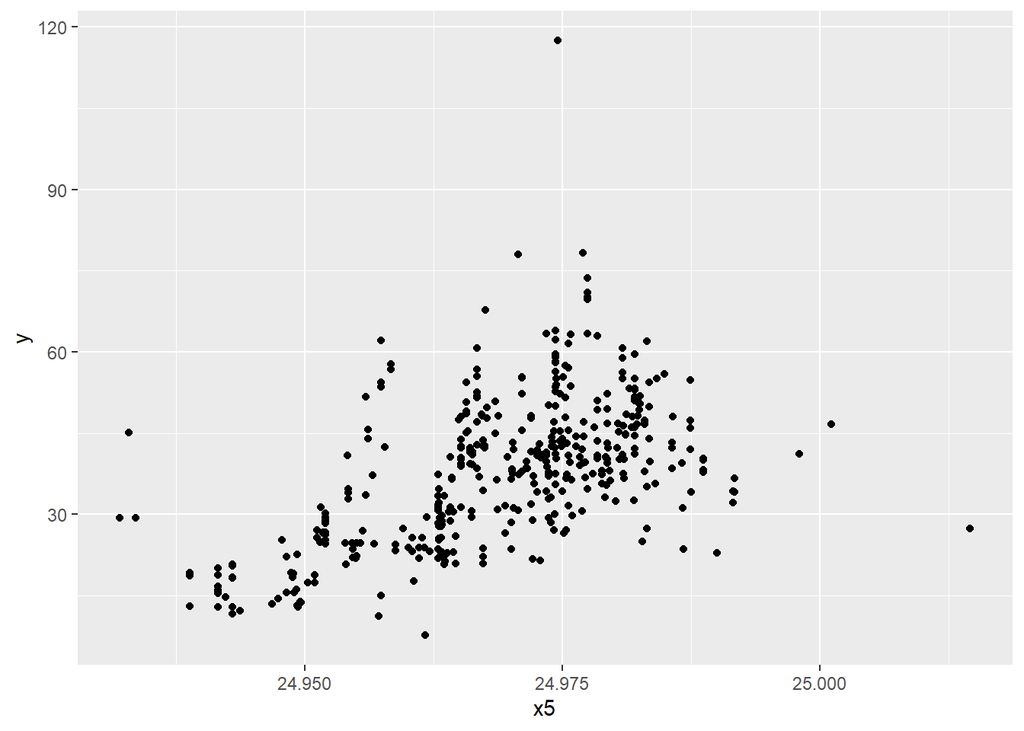

```r
ggplot(Real_estate_valuation_data_set, aes(x5,y)) + geom_point()
```

### Relationship between House Cost and Y-coordinate

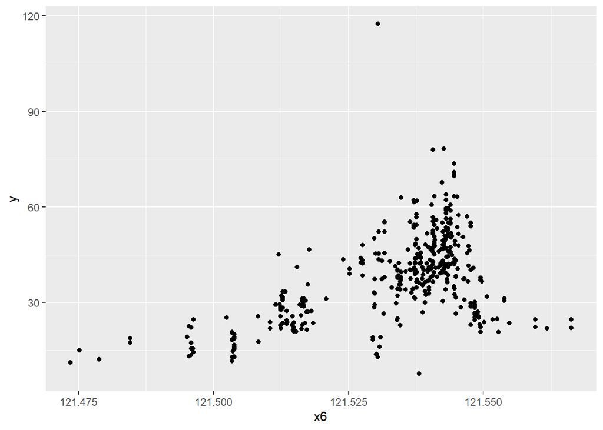

```r
ggplot(Real_estate_valuation_data_set, aes(x6,y)) + geom_point()
```

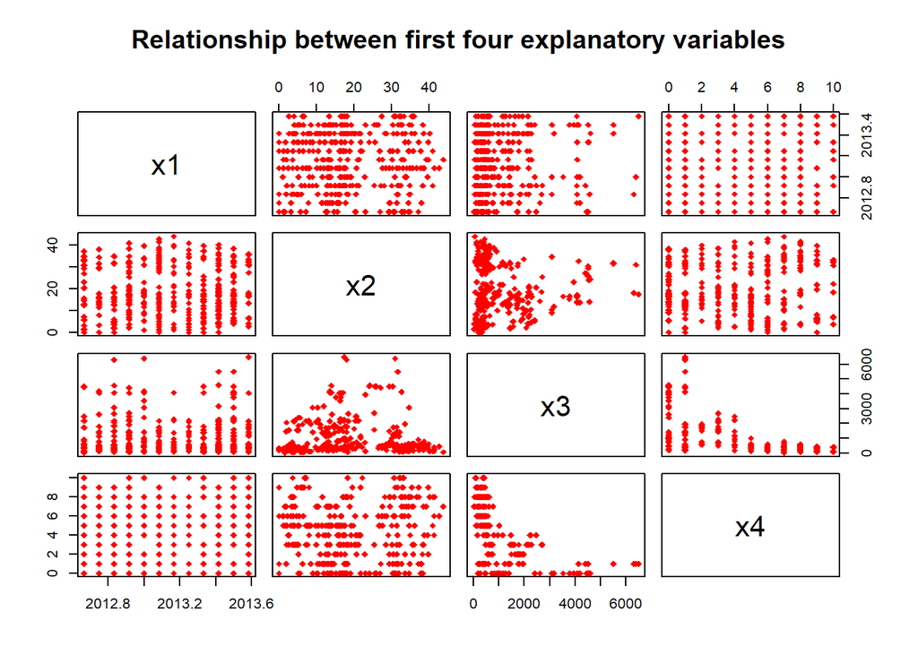

```r
pairs(Real_estate_valuation_data_set[,1:4], col= "red", pch=18, main= "Relationship between first four explanatory variables")
```

### Correlation between several explanatory variables

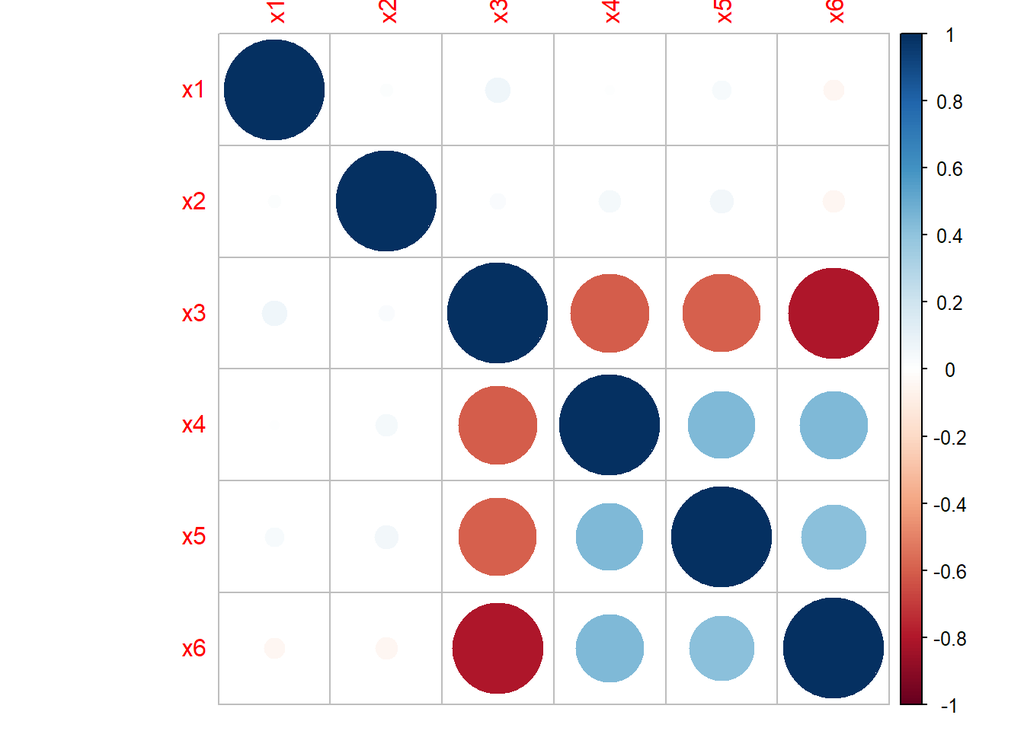

```r
correlations <- cor(Real_estate_valuation_data_set[,1:6])
corrplot(correlations, method="circle")
```

### Some Observations

- The house age ranges from 0 years to an age of up to nearly 44 years old. The house price across a year does not show an obvious trend. This could imply that the house age is not so relevant to the house price, but we will see that it is useful i our analysis below.
- There is a decreasing trend between the house price and distance to the train stations
- there is an increasing trend between the no of convenience stores and house cost.
- Majority of the buyers purchase the property that has a short distance to the nearest MRT station regardless of the age of the house.
- The number of convenience stores within walking distance is higher if the distance to the nearest MRT station is short ## 4. Model Building

## Model 1: Backward Elimination

```r
full=lm(y~., data = Real_estate_valuation_data_set) # Start with full model with all variables x1, x2, x3
drop1(full,test="F") # Manual F-test-based backward selection
```

```
## Single term deletions
##
## Model:
## y ~ x1 + x2 + x3 + x4 + x5 + x6
##        Df Sum of Sq   RSS    AIC F value    Pr(>F)
## <none>              31931 1813.0
## x1      1     858.2 32790 1822.0 10.9381  0.001026 **
## x2      1    3843.9 35775 1858.1 48.9952 1.064e-11 ***
## x3      1    3064.6 34996 1849.0 39.0614 1.037e-09 ***
## x4      1    2846.3 34778 1846.4 36.2790 3.827e-09 ***
## x5      1    2008.2 33940 1836.3 25.5962 6.382e-07 ***
## x6      1       5.1 31937 1811.1  0.0655  0.798203
## ---
## Signif. codes:  0 '***' 0.001 '**' 0.01 '*' 0.05 '.' 0.1 ' ' 1
```

```r
## x6 is the least significant variable by the partial F test
drop1(update(full, ~ . -x6), test = "F")
```

```
## Single term deletions
##
## Model:
## y ~ x1 + x2 + x3 + x4 + x5
##        Df Sum of Sq   RSS    AIC F value    Pr(>F)
## <none>              31937 1811.1
## x1      1     855.0 32792 1820.0  10.924  0.001033 **
## x2      1    3838.9 35775 1856.1  49.043 1.038e-11 ***
## x3      1    6181.9 38118 1882.3  78.976 < 2.2e-16 ***
## x4      1    2870.9 34807 1844.7  36.677 3.167e-09 ***
## x5      1    2064.9 34001 1835.0  26.380 4.354e-07 ***
## ---
## Signif. codes:  0 '***' 0.001 '**' 0.01 '*' 0.05 '.' 0.1 ' ' 1
```

```r
## Now x1 is the least significant, drop x6 then drop x1
drop1(update(full, ~ . -x6-x1), test = "F")
```

```
## Single term deletions
##
## Model:
## y ~ x2 + x3 + x4 + x5
##        Df Sum of Sq   RSS    AIC F value    Pr(>F)
## <none>              32792 1820.0
## x2      1    3820.2 36612 1863.7  47.648 1.954e-11 ***
## x3      1    5755.8 38547 1885.0  71.790 4.370e-16 ***
## x4      1    3023.6 35815 1854.5  37.713 1.943e-09 ***
## x5      1    2299.3 35091 1846.1  28.679 1.428e-07 ***
## ---
## Signif. codes:  0 '***' 0.001 '**' 0.01 '*' 0.05 '.' 0.1 ' ' 1
```

```r
model_1 = lm(y ~ x2 + x3 + x4 + x5, data = Real_estate_valuation_data_set)
summary(model_1)
```

```
##
## Call:
## lm(formula = y ~ x2 + x3 + x4 + x5, data = Real_estate_valuation_data_set)
##
## Residuals:
##     Min      1Q  Median      3Q     Max
## -34.522  -5.292  -1.579   4.264  76.466
##
## Coefficients:
##               Estimate Std. Error t value Pr(>|t|)
## (Intercept) -5.916e+03  1.113e+03  -5.317 1.74e-07 ***
## x2          -2.687e-01  3.893e-02  -6.903 1.95e-11 ***
## x3          -4.175e-03  4.928e-04  -8.473 4.37e-16 ***
## x4           1.165e+00  1.897e-01   6.141 1.94e-09 ***
## x5           2.386e+02  4.456e+01   5.355 1.43e-07 ***
## ---
## Signif. codes:  0 '***' 0.001 '**' 0.01 '*' 0.05 '.' 0.1 ' ' 1
##
## Residual standard error: 8.954 on 409 degrees of freedom
## Multiple R-squared:  0.5711, Adjusted R-squared:  0.5669
## F-statistic: 136.2 on 4 and 409 DF,  p-value: < 2.2e-16
```

The Backward Elimination method suggests the best fitted model is y_hat = -5916 - 0.268 x2 - 0.004 x3 + 1.165 x4 + 238.6 x5

### Analysis: Model 1

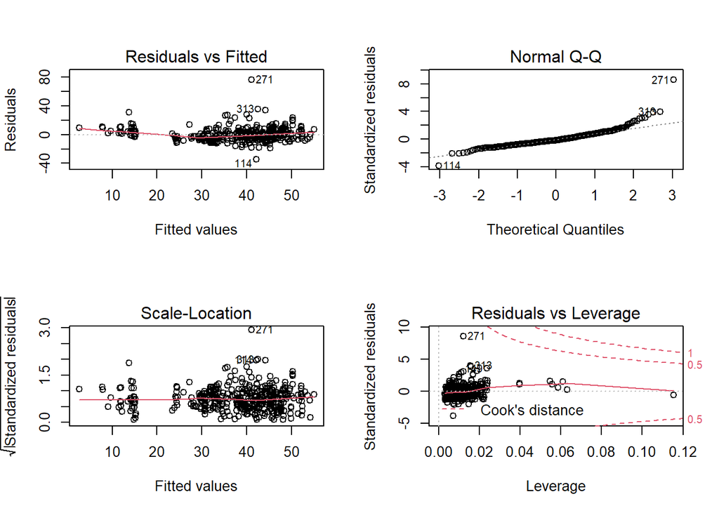

```r
par(mfrow=c(2,2))
plot(model_1 , which=1)
plot(model_1 , which=2)
plot(model_1 , which=3)
plot(model_1 , which=5)
```

- The relationship between fitted values and residuals are flat, which indicates the model has linear relationship and the residuals are roughly equal variance across the range of fitted values.
- The residuals do not fall close to the line and there are some deviations from normality, so it is assumed that the residuals are not normally distributed and this assumption is violated.
- The red line in the third plot is flat and the variances in the square root of the standardized residuals are consistently across fitted values. Therefore, this is a sign of homoscedasticity and the assumption is not violated.

-There are no values that fall in the upper and lower right hand side of the fourth plot beyond the red bands, so no influential cases.

## Model 2: Forward Selection

```r
null=lm(y~1, data = Real_estate_valuation_data_set)
add1(null, scope =full, test = "F")
```

```
## Single term additions
##
## Model:
## y ~ 1
##        Df Sum of Sq   RSS    AIC  F value    Pr(>F)
## <none>              76461 2162.5
## x1      1       586 75876 2161.3   3.1809   0.07524 .
## x2      1      3390 73071 2145.8  19.1150  1.56e-05 ***
## x3      1     34695 41767 1914.2 342.2393 < 2.2e-16 ***
## x4      1     24930 51531 2001.2 199.3182 < 2.2e-16 ***
## x5      1     22820 53641 2017.8 175.2718 < 2.2e-16 ***
## x6      1     20937 55524 2032.1 155.3593 < 2.2e-16 ***
## ---
## Signif. codes:  0 '***' 0.001 '**' 0.01 '*' 0.05 '.' 0.1 ' ' 1
```

```r
add1(update(null, ~ . +x3), scope = full, test = "F")
```

```
## Single term additions
##
## Model:
## y ~ x3
##        Df Sum of Sq   RSS    AIC F value    Pr(>F)
## <none>              41767 1914.2
## x1      1    1268.0 40499 1903.4 12.8684 0.0003744 ***
## x2      1    2859.1 38908 1886.8 30.2018 6.844e-08 ***
## x4      1    3273.6 38493 1882.4 34.9533 7.106e-09 ***
## x5      1    2579.5 39187 1889.8 27.0546 3.127e-07 ***
## x6      1      86.2 41681 1915.3  0.8499 0.3571189
## ---
## Signif. codes:  0 '***' 0.001 '**' 0.01 '*' 0.05 '.' 0.1 ' ' 1
```

```r
add1(update(null, ~ . +x3+x4), scope = full, test = "F")
```

```
## Single term additions
##
## Model:
## y ~ x3 + x4
##        Df Sum of Sq   RSS    AIC F value    Pr(>F)
## <none>              38493 1882.4
## x1      1    1046.1 37447 1873.0 11.4537 0.0007823 ***
## x2      1    3402.1 35091 1846.1 39.7504 7.470e-10 ***
## x5      1    1881.3 36612 1863.7 21.0681 5.902e-06 ***
## x6      1      23.5 38470 1884.2  0.2505 0.6170138
## ---
## Signif. codes:  0 '***' 0.001 '**' 0.01 '*' 0.05 '.' 0.1 ' ' 1
```

```r
add1(update(null, ~ . +x3+x4+x2), scope = full, test = "F")
```

```
## Single term additions
##
## Model:
## y ~ x3 + x4 + x2
##        Df Sum of Sq   RSS    AIC F value    Pr(>F)
## <none>              35091 1846.1
## x1      1   1089.49 34001 1835.0 13.1054 0.0003314 ***
## x5      1   2299.34 32792 1820.0 28.6790 1.428e-07 ***
## x6      1     52.53 35038 1847.5  0.6131 0.4340591
## ---
## Signif. codes:  0 '***' 0.001 '**' 0.01 '*' 0.05 '.' 0.1 ' ' 1
```

```r
add1(update(null, ~ . +x3+x4+x2+x5), scope = full, test = "F")
```

```
## Single term additions
##
## Model:
## y ~ x3 + x4 + x2 + x5
##        Df Sum of Sq   RSS    AIC F value   Pr(>F)
## <none>              32792 1820.0
## x1      1    855.04 31937 1811.1 10.9235 0.001033 **
## x6      1      2.03 32790 1822.0  0.0252 0.873895
## ---
## Signif. codes:  0 '***' 0.001 '**' 0.01 '*' 0.05 '.' 0.1 ' ' 1
```

```r
add1(update(null, ~ . +x3+x4+x2+x5+x1), scope = full, test = "F")
```

```
## Single term additions
##
## Model:
## y ~ x3 + x4 + x2 + x5 + x1
##        Df Sum of Sq   RSS    AIC F value Pr(>F)
## <none>              31937 1811.1
## x6      1    5.1353 31931 1813.0  0.0655 0.7982
```

```r
model_2 = lm(y~x3+x4+x2+x5+x1, data = Real_estate_valuation_data_set)
summary(model_2)
```

```
##
## Call:
## lm(formula = y ~ x3 + x4 + x2 + x5 + x1, data = Real_estate_valuation_data_set)
##
## Residuals:
##     Min      1Q  Median      3Q     Max
## -35.625  -5.373  -1.020   4.243  75.343
##
## Coefficients:
##               Estimate Std. Error t value Pr(>|t|)
## (Intercept) -1.596e+04  3.233e+03  -4.938 1.15e-06 ***
## x3          -4.353e-03  4.899e-04  -8.887  < 2e-16 ***
## x4           1.136e+00  1.876e-01   6.056 3.17e-09 ***
## x2          -2.694e-01  3.847e-02  -7.003 1.04e-11 ***
## x5           2.269e+02  4.417e+01   5.136 4.35e-07 ***
## x1           5.138e+00  1.554e+00   3.305  0.00103 **
## ---
## Signif. codes:  0 '***' 0.001 '**' 0.01 '*' 0.05 '.' 0.1 ' ' 1
##
## Residual standard error: 8.847 on 408 degrees of freedom
## Multiple R-squared:  0.5823, Adjusted R-squared:  0.5772
## F-statistic: 113.8 on 5 and 408 DF,  p-value: < 2.2e-16
```

- Its evident that the best fitted model suggested by manual forward selection is: y = -15960 - 0.004 x3 + 1.136 x4 - 0.2694 x2 + 226.9 x5 + 5.138 x1, and so we call it model_2.

### Analysis: Model 2

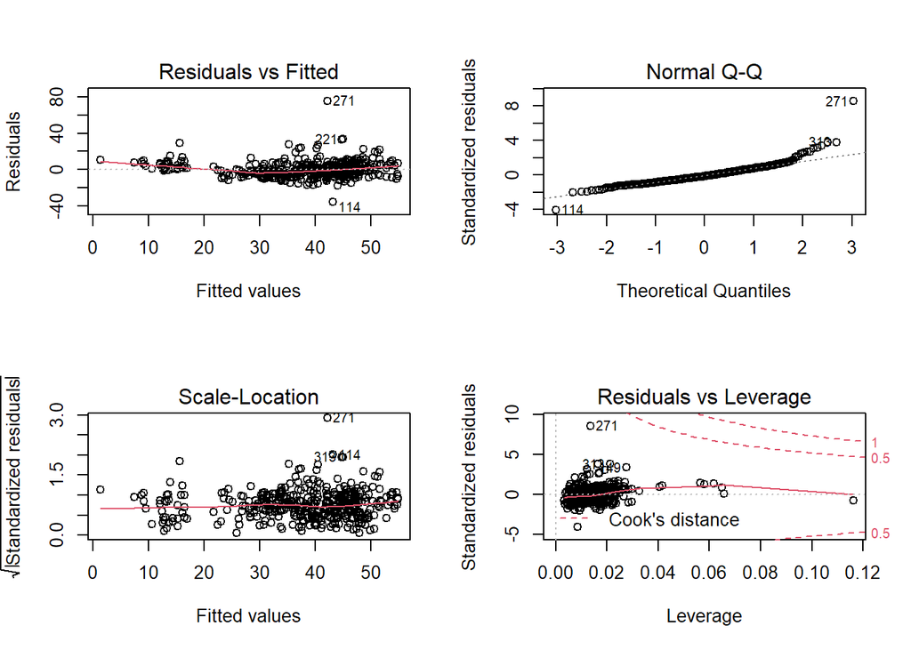

```r
par(mfrow=c(2,2))
plot(model_2 , which=1)
plot(model_2 , which=2)
plot(model_2 , which=3)
plot(model_2 , which=5)
```

## Comparison between models

```r
anova(model_1,model_2)
```

```
## Analysis of Variance Table
##
## Model 1: y ~ x2 + x3 + x4 + x5
## Model 2: y ~ x3 + x4 + x2 + x5 + x1
##   Res.Df   RSS Df Sum of Sq      F   Pr(>F)
## 1    409 32792
## 2    408 31937  1    855.04 10.924 0.001033 **
## ---
## Signif. codes:  0 '***' 0.001 '**' 0.01 '*' 0.05 '.' 0.1 ' ' 1
```